# Analyzing the NYC Subway Dataset

Roberto Argenta Coutinho

Thursday, May 21, 2015

# Overview

This document present the final project of Intro to Data Science which consist in a analysis about NYC Subway ridership. This document was created using R and R Markdown language.

# Section 1. Statistical Test

#### 1.1 Which statistical test did you use to analyze the NYC subway data? Did you use a one-tail or a two-tail P value? What is the null hypothesis? What is your p-critical value?

I used in my analysis the method ‘Mann-Whitney - Wilcoxon rank-sum’ test as presented during the training and ‘Welch Two Sample t-test’ . I decide use these methods because looks a great starting point to determine the null hypothesis using two samples. Based on the desciption, I used this test to be applied for two variables: rain and fog.

First I execute the test using fog:

*(Null Hypotheses - H0)* - There is no ridership difference between fog and no fog.

*(Alternative Hypotethes - H1)* - There is ridership difference between fog and no fog.

```r
with_fog <- subset(ny, fog == 1)
with_fog <- with_fog[,"ENTRIESn_hourly"]
with_fog_mean <- mean(with_fog)

without_fog <- subset(ny, fog == 0)
without_fog <- without_fog[,"ENTRIESn_hourly"]
without_fog_mean <- mean(without_fog)

t.test(without_fog, with_fog, var.equal = F)
```

```
##
##  Welch Two Sample t-test
##
## data:  without_fog and with_fog
## t = 2.2117, df = 431.11, p-value = 0.02751
## alternative hypothesis: true difference in means is not equal to 0
## 95 percent confidence interval:
##   28.62354 485.64695
## sample estimates:
## mean of x mean of y
##  1889.116  1631.981
```

```r
wilcox.test(without_fog, with_fog)
```

```
##
##  Wilcoxon rank sum test with continuity correction
##
## data:  without_fog and with_fog
## W = 9527300, p-value = 0.006688
## alternative hypothesis: true location shift is not equal to 0
```

**Welch p-value:** 0.0275126

**Wilcoxon p-value:** 0.0066884

**Foggy ridership Mean :** 1631.9809069

**No Foggy ridership Mean :** 1889.1161497

Then, let execute using rain variable:

*(Null Hypotheses - H0)* - There is no ridership difference between rain and no rain.

*(Alternative Hypotethes - H1)* - There is ridership difference between rain and no rain.

```r
with_rain <- subset(ny, rain == 1)
with_rain <- with_rain[,"ENTRIESn_hourly"]
with_rain_mean <- mean(with_rain)

without_rain <- subset(ny, rain == 0)
without_rain <- without_rain[,"ENTRIESn_hourly"]
without_rain_mean <- mean(without_rain)

t.test(without_rain, with_rain, var.equal = F)
```

```
##
##  Welch Two Sample t-test
##
## data:  without_rain and with_rain
## t = -5.0429, df = 14412, p-value = 4.641e-07
## alternative hypothesis: true difference in means is not equal to 0
## 95 percent confidence interval:
##  -253.6538 -111.6594
## sample estimates:
## mean of x mean of y
##  1845.539  2028.196
```

```r
wilcox.test(without_rain, with_rain, paired = F, correct = F)
```

```
##
##  Wilcoxon rank sum test
##
## data:  without_rain and with_rain
## W = 153640000, p-value = 5.482e-06
## alternative hypothesis: true location shift is not equal to 0
```

**Rainy ridership Mean :** 2028.1960355

**No Rainy ridership Mean :** 1845.5394387

#### 1.3 What results did you get from this statistical test? These should include the following numerical values: p-values, as well as the means for each of the two samples under test.

The statistic test demonstrated that are a difference of entries between rainy and non rainy days. It’s not completely conclusive, because it may have other factor that impact how many people use the subway.

#### 1.4 What is the significance and interpretation of these results?

At a first look, we can identify the difference of ridership during rainy and non rainy days.

# Section 2. Linear Regression

#### 2.1 What approach did you use to compute the coefficients theta and produce prediction for ENTRIESn_hourly in your regression model:

I used Gradient descent (as implemented in exercise 3.5) firstly using Numpy. After, I used as reference an R implementation of Gradient Descent.

```r
table <- aggregate(ENTRIESn_hourly ~ hour + rain + precipi + meantempi, data=ny,mean)

x <- table[, c("meantempi", "hour")]
y <- matrix(as.numeric(table$ENTRIESn_hourly), ncol=1)

num.iterations <- 75

# Function to standardize input values
zscore <- function(x, mean.val=NA) {
  if(is.matrix(x)) return(apply(x, 2, zscore, mean.val=mean.val))
  if(is.data.frame(x)) return(data.frame(apply(x, 2, zscore, mean.val=mean.val)))
  if(is.na(mean.val)) mean.val <- mean(x)
  sd.val <- sd(x)
  if(all(sd.val == 0)) return(x) # if all the values are the same
  (x - mean.val) / sd.val
}

# Standardize the features
x.scaled <- zscore(x)

# Gradient descent function
grad <- function(x, y, theta) {
  gradient <- (1 / nrow(y)) * (t(x) %*% ((x %*% t(theta)) - y))
  return(t(gradient))
}

gradient.descent <- function(x, y, alpha=0.1, num.iterations=500, threshold=1e-5, output.path=FALSE) {
  # Add x_0 = 1 as the first column
  m <- nrow(x)
  c0 <- rep(1, times = m)
  x <- cbind(c0, x)
  x <- apply(x, 2, as.numeric)

  num.features <- ncol(x)

  # Initialize the parameters
  theta <- matrix(rep(0, num.features), nrow=1)

  # Look at the values over each iteration
  theta.path <- theta
  for (i in 1:num.iterations) {

    theta <- theta - alpha * grad(x, y, theta)

    if(all(is.na(theta))) break
    theta.path <- rbind(theta.path, theta)
    #print(theta.path)
    if(i > 2) if(all(abs(theta - theta.path[i-1,]) < threshold)) break
  }

  if(output.path)
    return(theta.path)
  else
    return(theta.path[nrow(theta.path),])
}

scaled.theta <- gradient.descent(x=x.scaled, y=y, num.iterations=num.iterations, output.path=TRUE)

summary(lm(y ~ meantempi, data=x.scaled))
```

```
##
## Call:
## lm(formula = y ~ meantempi, data = x.scaled)
##
## Residuals:
##     Min      1Q  Median      3Q     Max
## -1287.8  -993.1  -409.6   512.0 14158.5
##
## Coefficients:
##             Estimate Std. Error t value Pr(>|t|)
## (Intercept)  1250.12      32.61  38.337   <2e-16 ***
## meantempi     -26.40      32.62  -0.809    0.418
## ---
## Signif. codes:  0 '***' 0.001 '**' 0.01 '*' 0.05 '.' 0.1 ' ' 1
##
## Residual standard error: 1344 on 1696 degrees of freedom
## Multiple R-squared:  0.0003861,  Adjusted R-squared:  -0.0002033
## F-statistic: 0.655 on 1 and 1696 DF,  p-value: 0.4184
```

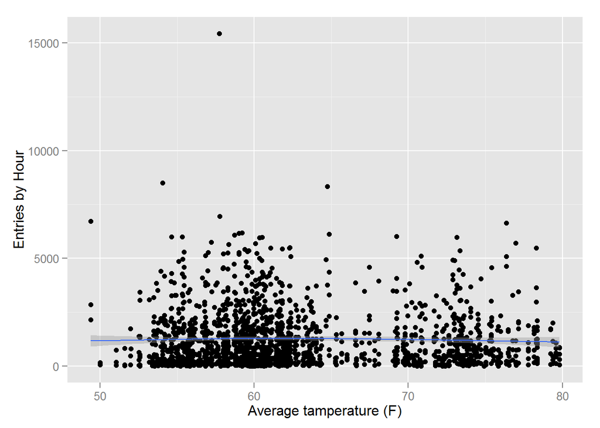

```r
dt <- data.frame(table)
ggplot(dt, aes(x = dt$meantempi, y=dt$ENTRIESn_hourly))+
  geom_point()+
  geom_smooth()+
  ylab("Entries by Hour")+
  xlab("Average tamperature (F)")
```

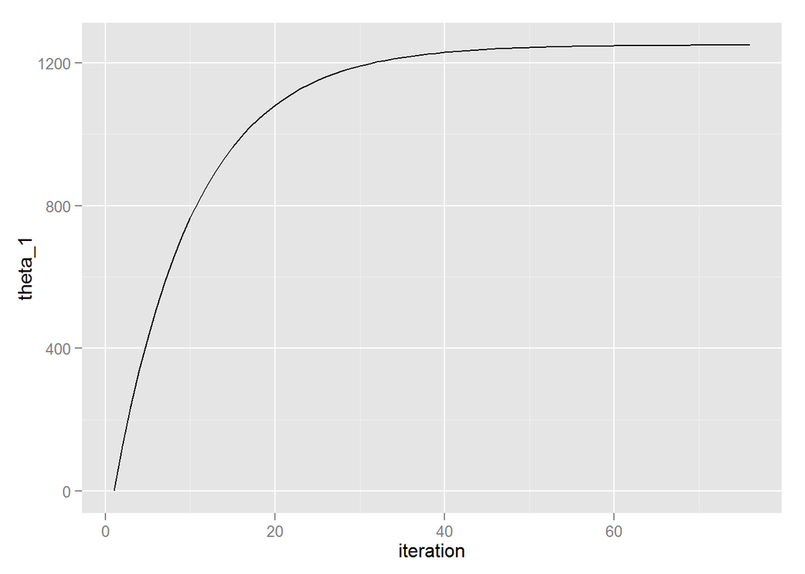

```r
qplot(1:(nrow(scaled.theta)), scaled.theta[,1], geom=c("line"), xlab="iteration", ylab="theta_1")
```

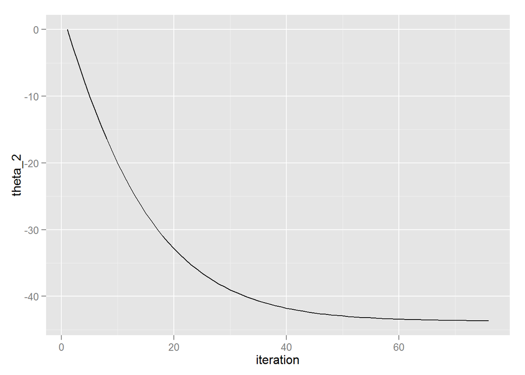

```r
qplot(1:(nrow(scaled.theta)), scaled.theta[,2], geom=c("line"), xlab="iteration", ylab="theta_2")
```

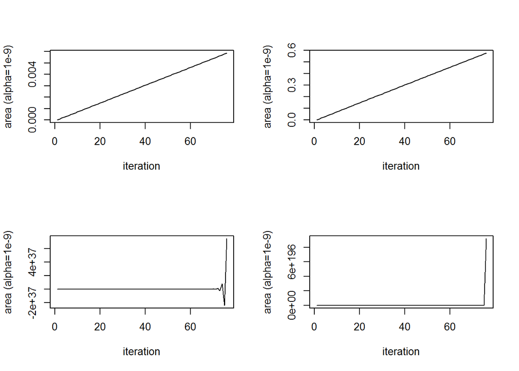

```r
# Look at output for various different alpha values
vary.alpha <- lapply(c(1e-9, 1e-7, 1e-3, 0.1), function(alpha) gradient.descent(x=x, y=y, alpha=alpha, num.iterations=num.iterations, output.path=TRUE))

par(mfrow = c(2, 2))
for (j in 1:4) {
  plot(vary.alpha[[j]][,2], ylab="area (alpha=1e-9)", xlab="iteration", type="l")
}
```

#### 2.4 What is your model’s R2 (coefficients of determination) value?

R-squared: 0.0003861

#### 2.5 What does this R2 value mean for the goodness of fit for your regression model? Do you think this linear model to predict ridership is appropriate for this dataset, given this R2 value?

This linear model is not appropriate for this dataset to predict ridership

# Section 3. Visualization

Please include two visualizations that show the relationships between two or more variables in the NYC subway data.

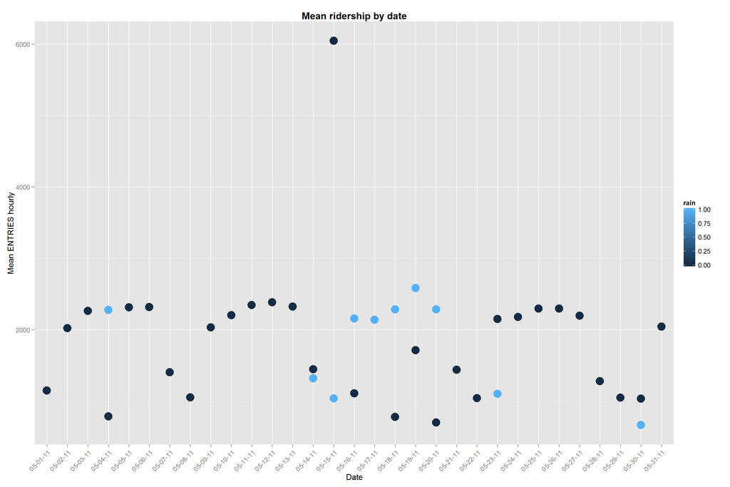

The plot above show the mean Entries by Date. The color differs when it was raining or not. We can observe that during the rainy and clear days the average is almost the same.

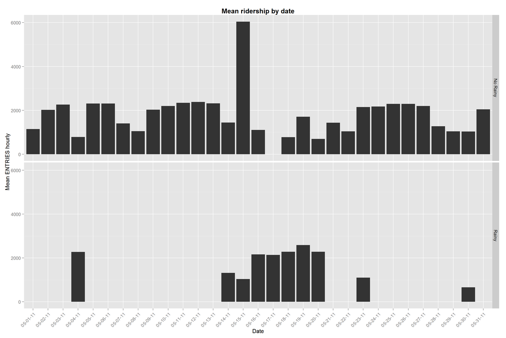

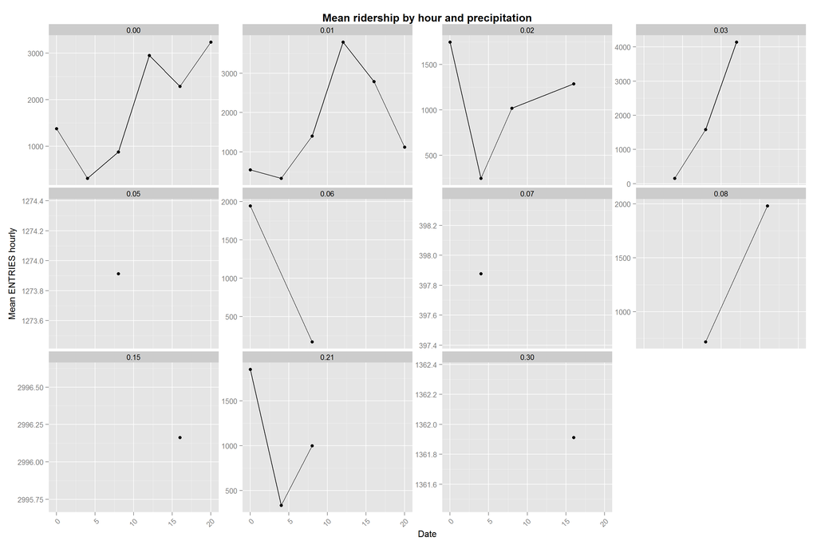

[figure not shown]

In the map above, we can observe the ridership distribution by station. The size represent average Entries by station, and we can see clearly that those stations located on Manhattan has more volume of ridership than others. It make sense, since the downtown has more stores, offices, companies, and the flow of people is higher.

Based on the graph, for a human being, it’s hard to notice a substatial difference between rainy and clear days.

# Section 4. Conclusion

#### 4.2 What analyses lead you to this conclusion?

Based on the dataset, the statistic methods used, plotting different correlation between variables, and a great feeling about how people need to get around every day. I don’t know the NYC subway, but here in the South of Brazil, usually peoplo goes to work by bus or car. Those who goes every day by bus, during rainy day can choose other transportation. Many people leave the car in house’s garage and pick up bus to get around to the city. During rainy days those people may choose by take a cab, but usually they will get bus.

In NYC I think that is quite different. As far I know about central area, is to much expensive ride a car and hard to find a place to park. Furthermore, I imagine the NYC subway is a high level service, with quality, fast and confort. So my conclusion is that indiferently when it’s rainy or not the NYC subwar still is the best choice for those who need to go work, medic, education, etc…

# Section 5. Reflection

#### 5.1 Please discuss potential shortcomings of the methods of your analysis, including: Dataset, Analysis, such as the linear regression model or statistical test.

**Analysis:**

My formal graduation and expertise is Computer Science. Also, I like to analyze data trying to find insights and currently I work as a Data Architect within a project for a multinational big player computer company. I am not a statistician, and many statistic’s concepts need to be learned to understand and apply correctly the methods. So one potential shortcoming may be that I have applied incorrectly the presented statistic’s methods which may have led to make a wrong analysis. For that I will review all implementations and concepts.

Linear Regression is a common and very used method, but Gradient Descent is new to me and I’ll review the steps and improve my implementation and analysis

**Dataset:**

Maybe, the dataset could include more variables that would help us to understand some variations on ridership such as:

1. Price - The price may impact directly how people choose to go by subway, or choose other way like bus, cab, bike. One simple question would be: Do more people ride the subway when the price decrease?
2. Snow - When it’s snowing may impact how many people goes by subway?
3. Special events or date - Do more people get around during periods of time where has more cultural options like special shows, theater or sport events.

# References

http://en.wikipedia.org/wiki/Mann%E2%80%93Whitney_U_test

http://science.nature.nps.gov/im/datamgmt/statistics/r/formulas/

https://www.youtube.com/watch?v=nRAAAp1Bgnw

http://www.r-tutor.com/elementary-statistics/simple-linear-regression/coefficient-determination

http://en.wikipedia.org/wiki/Coefficient_of_determination

http://en.wikipedia.org/wiki/Goodness_of_fit

http://www.statisticsviews.com/details/feature/5722691/Getting-to-the-Bottom-of-Regression-with-Gradient-Descent.html

http://pt.wikipedia.org/wiki/R%C2%B2

http://stats.stackexchange.com/questions/30394/how-to-perform-two-sample-t-tests-in-r-by-inputting-sample-statistics-rather-tha

http://www.r-bloggers.com/linear-regression-by-gradient-descent/

http://www.holehouse.org/mlclass/04_Linear_Regression_with_multiple_variables.html